# Assignment 3: Machine Learning

M.D’Arcy 40302488

## Abstract

This report builds on assignment 2 using its feature classification,we will in this report examine methods of machine learning to solve classification problems. classifiers will be fit and evaluated for our image data in order to see whether the models can predict the class labels for unseen images.

## Section 1 Introduction

We first split the data into a training and test set,We randomly shuffle our data and split in the ratio 80:20, as seen below in the table. The focus will be on NR_pix which counts the number of black pixels in the image and aspect ratio which computes width/height of pixels in the image. A logistic regression model is fit for the combination of aspect_ratio and NR_pix under binomial.

Using our summary statistics we can see the following:

Our deviance residuals can be used to check the model fit at each observation for generalized linear models. We see our model fits well in the 1st to third quartile and well at the median at 0.1299. We can use the error rate of >1 to conclude that our min and max are outliers and not fit well to out model.

The Akaike information criterion (AIC) is an information-theoretic measure that describes the quality of a model. A model with a low AIC is characterized by low complexity and a good fit. With a relatively low AIC it is accepted.

The information about Fisher scoring iterations is just verbose output of iterative weighted least squares. A high number of iterations may be a cause for concern indicating that the algorithm is not converging properly the low outcome of 6 means our algorithm is working.

Next we plot a fitted curve to inspect the data. we compare this with our new data column of is.letter to check whether the two feature are similar to the results of the letter data set. We have similar Max values along with our mean and median which means these two features indicate letter well.

## 1.1

```r
set.seed(42)
#test data sets:
# randomly shuffle rows:
data_shuffled <- data[sample(nrow(data)),]
head(data_shuffled)
```

|  | label | index | nr_pix | row_with_1 | cols_with_1 | rows_with_3p | cols_with_3p | aspect_ratio | no_neigh_left | no_neigh_right | no_neigh_above | no_neigh_below | no_neigh_vert | no_neigh_horiz | eyes | None | None | is.letter | multiLetter2 |
| --- | --- | --- | --- | --- | --- | --- | --- | --- | --- | --- | --- | --- | --- | --- | --- | --- | --- | --- | --- |
| 49 | g | 1 | 25 | 3 | 0 | 5 | 4 | 0.60000000 | 11 | 9 | 0.3200000 | 4 | 4 | 11 | 1 | 1 | 0 | yes | 1 |
| 65 | i | 1 | 21 | 1 | 0 | 0 | 2 | 0.50000000 | 9 | 8 | 0.1428571 | 1 | 2 | 1 | 2 | 2 | 0 | yes | 1 |
| 74 | j | 2 | 21 | 7 | 1 | 3 | 2 | 0.75000000 | 8 | 5 | 0.5238095 | 6 | 5 | 8 | 2 | 2 | 0 | yes | 1 |
| 122 | xlaim | 2 | 56 | 0 | 0 | 14 | 4 | 0.07142857 | 12 | 12 | 0.2142857 | 6 | 6 | 0 | 2 | 2 | 0 | no | 0 |
| 140 | xlaim | 20 | 75 | 0 | 0 | 15 | 5 | 0.26666667 | 13 | 13 | 0.2133333 | 8 | 8 | 0 | 2 | 2 | 0 | no | 0 |
| 128 | xlaim | 8 | 96 | 0 | 0 | 16 | 6 | 0.18750000 | 14 | 14 | 0.1562500 | 10 | 5 | 0 | 2 | 2 | 0 | no | 0 |

```r
# first 80% will be training data:
training_data = data_shuffled[1:112,]
test_data = data_shuffled[113:140,]



# Lets fit a logistic regression model using aspect_ratio:
#-----------------------------------------------#
#            log                                #
#-----------------------------------------------#

glmfit <- glm(is.letter ~ aspect_ratio+nr_pix, data = training_data, family = 'binomial')
summary(glmfit)
```

```
Call:
glm(formula = is.letter ~ aspect_ratio + nr_pix, family = "binomial",
    data = training_data)

Deviance Residuals:
    Min       1Q   Median       3Q      Max
-2.8171  -0.1362   0.1299   0.2803   2.3463

Coefficients:
             Estimate Std. Error z value Pr(>|z|)
(Intercept)   9.92782    1.90702   5.206 1.93e-07 ***
aspect_ratio -2.36890    1.21130  -1.956   0.0505 .
nr_pix       -0.20195    0.04045  -4.992 5.97e-07 ***
---
Signif. codes:  0 ‘***’ 0.001 ‘**’ 0.01 ‘*’ 0.05 ‘.’ 0.1 ‘ ’ 1

(Dispersion parameter for binomial family taken to be 1)

    Null deviance: 152.36  on 111  degrees of freedom
Residual deviance:  53.58  on 109  degrees of freedom
AIC: 59.58

Number of Fisher Scoring iterations: 6
```

```r
# To plot the fitted curve, let's make a data frame containing the predicted
# values across the range of feature values (i.e. across the x-axis)
#-----------------------------------------------#
#             fit cur                           #
#-----------------------------------------------#

x.range = range(training_data[["aspect_ratio"]])
x1.range = range(training_data[["nr_pix"]])

x.values = seq(x.range[1],x.range[2],length.out=1000)

x1.values = seq(x1.range[1],x1.range[2],length.out=1000)


fitted.curve <- data.frame(aspect_ratio = x.values, nr_pix = x1.values)
summary(fitted.curve)
```

```
  aspect_ratio      nr_pix
 Min.   :0.00   Min.   :12.00
 1st Qu.:0.25   1st Qu.:33.25
 Median :0.50   Median :54.50
 Mean   :0.50   Mean   :54.50
 3rd Qu.:0.75   3rd Qu.:75.75
 Max.   :1.00   Max.   :97.00
```

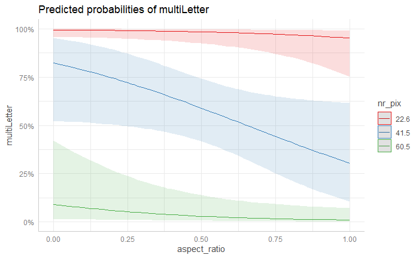

```r
fitted.curve[["is.letter"]] = predict(glmfit, fitted.curve, type="response")



#-----------------------------------------------#
#                           plt                 #
#-----------------------------------------------#

#https://stackoverflow.com/questions/64222986/plotting-logistic-regression-with-multiple-predictors
# Plot the training data and the fitted curve:

library(ggeffects)

training_data$multiLetter = as.numeric(training_data$is.letter == "yes")
mdl = glm(multiLetter ~ aspect_ratio +nr_pix,data=training_data,family="binomial")
plot(ggpredict(mdl,c("aspect_ratio[all]","nr_pix"), title = "Multi varaible logistcal regression"))
```

```r
# Assuming a p>0.5 cut-off, calculate accuracy on the training data
# ~~~~~~~~~~~~~~~~~~~~~~~~~~~~~~~~~~~~~~~~~~~~~~~~~~~~~~~~~~~~~~~~~

#-----------------------------------------------#
#             acc training                       #
#-----------------------------------------------#

training_data[["predicted_val"]] = predict(glmfit, training_data, type="response")
training_data[["predicted_class"]] = 0
training_data[["predicted_class"]][training_data[["predicted_val"]] > 0.5] = 1



correct_items = training_data[["predicted_class"]] == training_data[["multiLetter"]]


# proportion correct:
nrow(training_data[correct_items,])/nrow(training_data)
```

```
[1] 0.9017857
```

```r
# proportion incorrect:
nrow(training_data[!correct_items,])/nrow(training_data)
```

```
[1] 0.09821429
```

```r
# Assuming a p>0.5 cut-off, calculate accuracy on the test data
# ~~~~~~~~~~~~~~~~~~~~~~~~~~~~~~~~~~~~~~~~~~~~~~~~~~~~~~~~~~~~~

#-----------------------------------------------#
#              acc test                         #
#-----------------------------------------------#
test_data$multiLetter1 = as.numeric(test_data$is.letter == "yes")

test_data[["predicted_val"]] = predict(glmfit, test_data, type="response")
test_data[["predicted_class"]] = 0
test_data[["predicted_class"]][test_data[["predicted_val"]] > 0.5] = 1

correct_items1 = test_data[["predicted_class"]] == test_data[["multiLetter1"]]

# proportion correct:
nrow(test_data[correct_items1,])/nrow(test_data)
```

```
[1] 1
```

```r
# proportion incorrect:
nrow(test_data[!correct_items1,])/nrow(test_data)
```

```
[1] 0
```

```r
#-----------------------------------------------#
#              confusion matrix                 #
#-----------------------------------------------#
library(caret)
#use model to predict probability of default
predicted <- predict(glmfit, test_data, type="response")


#create confusion matrix
confusionMatrix(as.factor(test_data$multiLetter1), as.factor(test_data$predicted_class))
```

```
Confusion Matrix and Statistics

          Reference
Prediction  0  1
         0 13  0
         1  0 15

               Accuracy : 1
                 95% CI : (0.8766, 1)
    No Information Rate : 0.5357
    P-Value [Acc > NIR] : 2.571e-08

                  Kappa : 1

 Mcnemar's Test P-Value : NA

            Sensitivity : 1.0000
            Specificity : 1.0000
         Pos Pred Value : 1.0000
         Neg Pred Value : 1.0000
             Prevalence : 0.4643
         Detection Rate : 0.4643
   Detection Prevalence : 0.4643
      Balanced Accuracy : 1.0000

       'Positive' Class : 0
```

We repeat 1.1 but using 5- fold cross validation over all 140 items with no separate test and training data due to the nature of fold cross validation. K-Fold CV is where a given data set is split into a K number of sections/folds where each fold is used as a testing set at some point. Lets take the scenario of 5-Fold cross validation(K=5). Here, the data set is split into 5 folds. In the first iteration, the first fold is used to test the model and the rest are used to train the model. In the second iteration, 2nd fold is used as the testing set while the rest serve as the training set. This process is repeated until each fold of the 5 folds have been used as the testing set. We create a generalized linear model, with two class “yes” and “no” for if the sample is a letter or symbol. the summary of sample sized being 112, our accuracy is reported as 0.9214 which is similar to 1.1 results.

The Kappa statistic is a metric that compares an Observed Accuracy with an Expected Accuracy (random chance). The kappa statistic is used not only to evaluate a single classifier, but also to evaluate classifiers among themselves. In addition, it takes into account random chance (agreement with a random classifier), which generally means it is less misleading than simply using accuracy as a metric, with our 0.83 value it still yields an impressive accuracy.

## 1.2

```r
# Cross Validation
library(caret)
kfoldsk = 5
train_control <- trainControl(method="cv", number=kfoldsk,
                              savePredictions=TRUE,
                              classProbs = TRUE)


# train the model
model <- train(is.letter~nr_pix + aspect_ratio, data=data,
               trControl=train_control, method="glm", family="binomial")
# summarize results
print(model)
```

```
Generalized Linear Model

140 samples
  2 predictor
  2 classes: 'no', 'yes'

No pre-processing
Resampling: Cross-Validated (5 fold)
Summary of sample sizes: 112, 112, 112, 112, 112
Resampling results:

  Accuracy   Kappa
  0.9214286  0.8390939
```

```r
library(caret)


#create confusion matrix
#confusion Matrix(model$pred$yes >0.5,model$pred$obs == "yes")
```

We plot an ROC curve foe the classier. An ROC curve (receiver operating characteristic curve) is a graph showing the performance of a classification model at all classification thresholds. This curve plots two parameters:

True Positive Rate False Positive Rate

AUC stands for “Area under the ROC Curve.” That is, AUC measures the entire two-dimensional area underneath the entire ROC curve from (0,0) to (1,1). AUC ranges in value from 0 to 1. A model whose predictions are 100% wrong has an AUC of 0.0; one whose predictions are 100% correct has an AUC of 1.0 Our AUC-ROC is 0.97 also supporting the two earlier results.

## 1.3

```
***MLeval: Machine Learning Model Evaluation***
Input: caret train function object
Not averaging probs.
Group 1 type: cv
Observations: 140
Number of groups: 1
Observations per group: 140
Positive: yes
Negative: no
Group: Group 1
Positive: 80
Negative: 60
***Performance Metrics***
Group 1 Optimal Informedness = 0.875
Group 1 AUC-ROC = 0.97
```

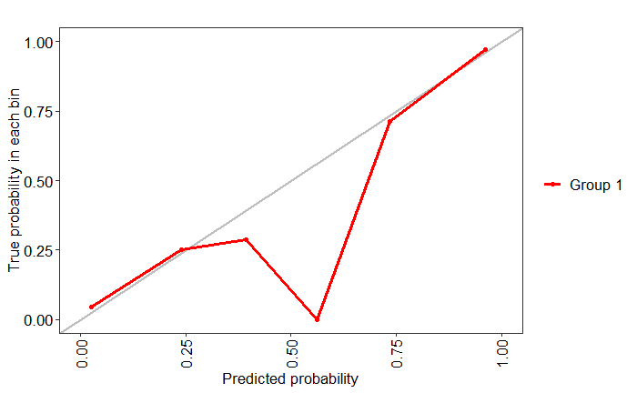

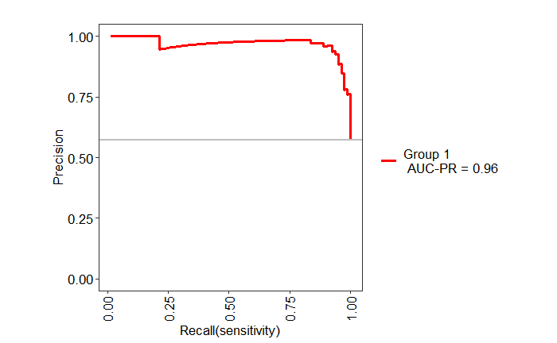

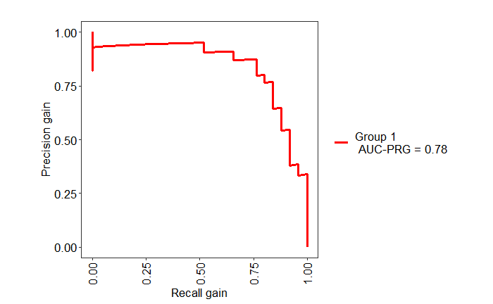

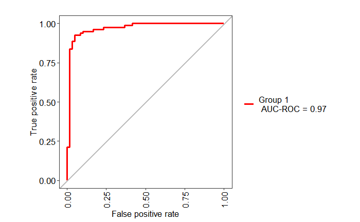

```r
#. Plot an ROC curve for the classifier. Hint: check out the MLeval library and the example R code
#provided for Topic 20 – Evaluation. Briefly interpret the results.



library(MLeval)
res <- evalm(model)
```

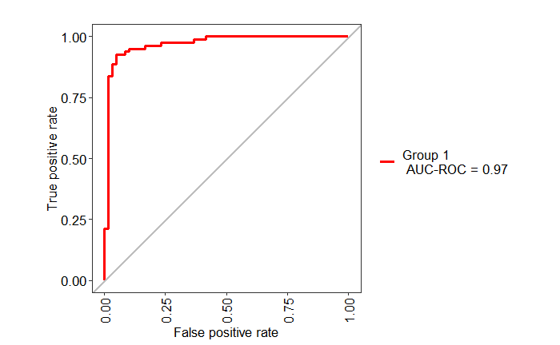

```r
res$roc
```

```r
NA
NA
NA
NA
NA
NA
```

## Section 2 Introduction

First I split up and create a new data frame using a,j and symbol set.

Wrapper methods evaluate multiple models using procedures that add and/or remove predictors to find the optimal combination that maximizes model performance.I checked multiple combinations of predictors to asses whether they improved the model on the basis of separation of their scatter plots

This can also be verified by the accuracy produced on our data which is 1 0.9473684 0.9473684 0.9342105 0.9210526 0.9210526 0.9210526 Respectively through the folds we see from point 3 that the accuracy is repeated but follows on the trend of over 90% accuracy at predicating.

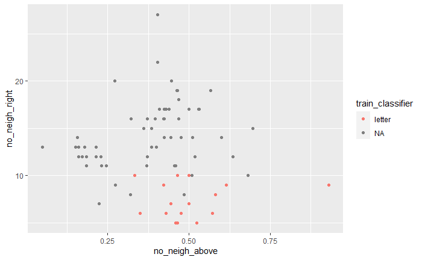

```r
#k-nearest classification odd values of k between 1-13 using any 4 features  a-j 76
#Creation of new data set
#first I split data frame
data21 <-data.frame(data[1:8, ])
data23 <-data.frame(data[73:80, ])
data22 <-data.frame(data[81:140, ])
dataf<- rbind(data21, data23,data22)
library(ggplot2)
library(varhandle)
#train_classifier = factor(train$label,auto_class_conversion = TRUE, verbose = FALSE)

dataf$train_classifier[dataf$label %in% c("a","j")] = "letter"
data$train_classifier[data$label %in% c("sad")] <- "sad"
data$train_classifier[data$label %in% c("smiley")] <- "smiley"
data$train_classifier[data$label %in% c( "xlaim")] <- "xclaim"
View(dataf)

#non-letters

# scatter plot
scatterplot <- ggplot(dataf, aes(x=no_neigh_above, y=no_neigh_right, color=train_classifier)) +
  geom_point()
scatterplot
```

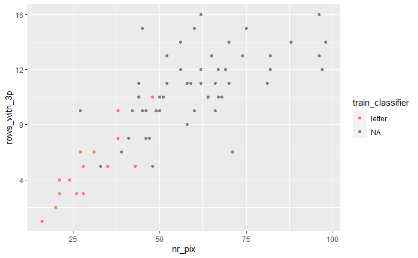

```r
scatterplot1 <- ggplot(dataf, aes(x=nr_pix, y=rows_with_3p, color=train_classifier)) +
  geom_point()
scatterplot1
```

```r
set.seed(42)
#Feature selection
#no_neigh_above
#no_neigh_right
#rows_with_3p
#NR_pix


train= dataf

length(train)
```

```
[1] 20
```

```r
library(ISLR)
library(class) # for `kn`, and other classifiers


train.X = cbind(dataf$nr_pix,dataf$no_neigh_above,dataf$no_neigh_right,dataf$rows_with_3p)
summary(train.X)
```

```
       V1              V2                V3              V4
 Min.   :16.00   Min.   :0.04839   Min.   : 5.00   Min.   : 1.000
 1st Qu.:42.75   1st Qu.:0.27273   1st Qu.:10.00   1st Qu.: 7.000
 Median :56.00   Median :0.42339   Median :12.00   Median :10.000
 Mean   :54.39   Mean   :0.40033   Mean   :12.68   Mean   : 9.776
 3rd Qu.:67.25   3rd Qu.:0.47835   3rd Qu.:16.00   3rd Qu.:13.000
 Max.   :98.00   Max.   :0.93023   Max.   :27.00   Max.   :16.000
```

```r
test.X = train.X

train.Direction = dataf$multiLetter2



ks = c(1,3,5,7,9,11,13)

accuracies = c()

# a for loop

for (k in ks){
  print(k)
  knn.pred=knn(train.X,test.X,train.Direction,k=k)
  accuracies = cbind(accuracies, mean(knn.pred==train.Direction))
}
```

```
[1] 1
[1] 3
[1] 5
[1] 7
[1] 9
[1] 11
[1] 13
```

```r
View(accuracies)
```

## 2.2

We perform our k - nearest -neighbor classification using 5 fold cross-validation of the same four features .We examine the cross validate accuracy for each value of k again odd vales of 1-13 inclusive. Our set contain 76 samples with our 4 predictors and 4 classes: ‘letter’, ‘sad’, ‘smiley’, ‘xclaim’. Our summary statics are as follow:

```r
# Cross-validation KNN in R

require(class) # for `knn`
require(ggplot2) # for plotting

data21 <-data.frame(data[1:8, ])
data23 <-data.frame(data[73:80, ])
data22 <-data.frame(data[81:140, ])
dataf<- rbind(data21, data23,data22)
library(ggplot2)
library(varhandle)
#train_classifier = unfactor(train$label,auto_class_conversion = TRUE, verbose = FALSE)

dataf$train_classifier[dataf$label %in% c("a","j")] = "letter"
data$train_classifier[data$label %in% c("sad")] <- "sad"
data$train_classifier[data$label %in% c("smiley")] <- "smiley"
data$train_classifier[data$label %in% c( "xlaim")] <- "xclaim"
View(dataf)
# Perform crossvalidation

set.seed(42)
# The caret package for R can automate the crossvalidation procedure
dataf$classifier = dataf$train_classifier

library(caret)
ks = c(1,3,5,7,9,11,13)

# define training control
train_control <- trainControl(method="cv", number=kfoldsk)

tune_grid <- expand.grid(k = ks)

# train the model
model <- train(classifier~nr_pix + no_neigh_above + no_neigh_right + rows_with_3p, data=dataf,
               trControl=train_control, tuneGrid=tune_grid, method="knn")
# summarize results
print(model)
```

```
k-Nearest Neighbors

76 samples
 4 predictor
 4 classes: 'letter', 'sad', 'smiley', 'xclaim'

No pre-processing
Resampling: Cross-Validated (5 fold)
Summary of sample sizes: 61, 61, 61, 61, 60
Resampling results across tuning parameters:

  k   Accuracy   Kappa
   1  0.6600000  0.5462699
   3  0.5525000  0.4033756
   5  0.5266667  0.3681108
   7  0.5391667  0.3847775
   9  0.5391667  0.3848958
  11  0.5933333  0.4573060
  13  0.4883333  0.3152484

Accuracy was used to select the optimal model using the largest value.
The final value used for the model was k = 1.
```

```r
acc_2.2 = model$results$Accuracy
```

## 2.3

For the best value of K we report the confusion matrix and examine which pairs of classes are the most difficult to discriminate.

Here a 100 accuracy is reported which correctly classified the entire set using the predictors as shown below.

I again checked if there was a mistake but printed out each set and compared by hand and was seen that it matched 100%.

In this case I cant say which pairs of classes were to most difficult to discriminate against due to its 100% accuracy.

```r
# Perform cross validation


# The caret package for R can automate the cross validation procedure
dataf$classifier = dataf$train_classifier

library(caret)
ks = 1

# define training control
train_control <- trainControl(method="cv", number=5)

tune_grid <- expand.grid(k = ks)

# train the model
model <- train(classifier~nr_pix + no_neigh_above + no_neigh_right + rows_with_3p, data=dataf,
               trControl=train_control, tuneGrid=tune_grid, method="knn")

knn_cv_pred = predict(model)

table(knn_cv_pred,dataf$classifier)
```

```
knn_cv_pred letter sad smiley xclaim
     letter     16   0      0      0
     sad         0  20      0      0
     smiley      0   0     20      0
     xclaim      0   0      0     20
```

## 2.4

Which reference to figure 2.17 of the ISLR textbook which shows the classification error rate over the training set and the cross validated classification error rate for each value of 1/k

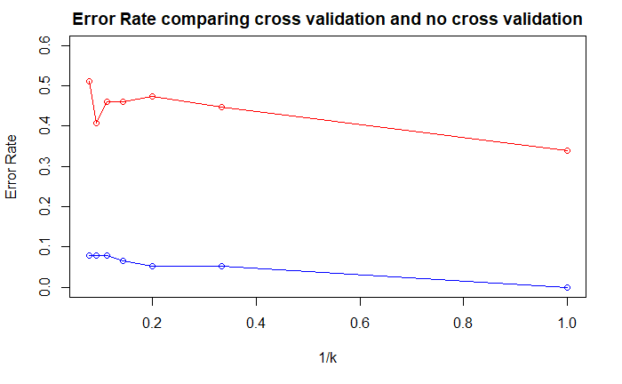

```r
#2.1
ks = c(1,1/3,1/5,1/7,1/9,1/11,1/13)

er_1 = 1- accuracies
#2.2
er_2 = 1- acc_2.2



  #Error Rate plot
# classification error from 2.1
plot(ks,er_1,type='o',xlab="1/k",ylim=c(0,0.6),  ylab="Error Rate",col="blue", main = "Error Rate comparing cross validation and no cross validation")

# cross validated classification and accuracy rate from 2.2
lines(ks,er_2,type='o',col="red")
```

## Section 3

In section 3 a larger data set was provided to us which consist of 80 training items for each of the 13 image types (1040 training items in total). The features are in the same format as Assignment 2. In this section, you are to perform classification with respect to the 13 fine-grained image categories, using all the features.

## 3.1

Classification is performed with random forests using 5-fold cross-validation. Near the top of the classifiers hierarchy is the random Forrest classier. A large number of individual trees in the random Forrest spits out a class prediction and the class with the most votes becomes the model predictions.The reason we favor Random forests is because A large number of relatively uncorrelated models (trees) operating as a committee will outperform any of the individual constituent models.

The most successful run is 175 6 which we examine further in section 3.2

```r
set.seed(42)

library(caret)
library(ranger)
library(grid)
library(randomForest)
getwd()
```

```
[1] "C:/Users/megan/OneDrive/Desktop/a3_40302488"
```

```r
setwd("C:/Users/megan/OneDrive/Desktop/a3_40302488")

#create a list of the files from your target directory
df_csv <- list.files(path= ".",
                     pattern="all_features.csv",
                     full.names = TRUE)

features <- read.table(df_csv)



#removing index and blank col for training.
reducedfeaturesDataset <-features[c(1, 3:15)]


names(reducedfeaturesDataset) <- c("label", "nr_pix", "row_with_1",
                                   "cols_with_1", "rows_with_3p", "cols_with_3p", "aspect_ratio","no_neigh_left", "no_neigh_right", "no_neigh_horiz","no_neigh_above","no_neigh_below","no_neigh_vert","diagonalness")

#adding labels as a factors to predict on
reducedfeaturesDataset$label <- as.factor(reducedfeaturesDataset$label)
reducedfeaturesDataset
```

| label | nr_pix | row_with_1 | cols_with_1 | rows_with_3p | cols_with_3p | aspect_ratio | no_neigh_left | no_neigh_right | no_neigh_horiz | no_neigh_above | no_neigh_below | no_neigh_vert | diagonalness |
| --- | --- | --- | --- | --- | --- | --- | --- | --- | --- | --- | --- | --- | --- |
| a | 39 | 0 | 0 | 9 | 6 | 1.08333333 | 1 | 6 | 8 | 11 | 11 | 15 | 9 |
| a | 50 | 0 | 1 | 10 | 9 | 1.16666667 | 0 | 8 | 10 | 11 | 10 | 6 | 9 |
| a | 24 | 2 | 0 | 5 | 5 | 0.75000000 | 1 | 5 | 4 | 5 | 9 | 6 | 3 |
| a | 36 | 1 | 0 | 9 | 5 | 1.30000000 | 0 | 11 | 10 | 10 | 8 | 11 | 15 |
| a | 28 | 0 | 3 | 6 | 4 | 1.50000000 | 1 | 7 | 8 | 6 | 8 | 14 | 13 |
| a | 37 | 0 | 1 | 8 | 7 | 1.10000000 | 0 | 7 | 9 | 9 | 10 | 9 | 8 |
| a | 45 | 0 | 2 | 10 | 7 | 1.27272727 | 1 | 8 | 10 | 9 | 8 | 7 | 11 |
| a | 41 | 1 | 1 | 9 | 6 | 0.92307692 | 1 | 7 | 9 | 12 | 11 | 13 | 11 |
| a | 53 | 1 | 0 | 10 | 11 | 0.84615385 | 2 | 11 | 12 | 7 | 10 | 7 | 11 |
| a | 29 | 1 | 1 | 6 | 6 | 1.12500000 | 0 | 5 | 7 | 6 | 5 | 3 | 6 |

[output cut: 990 more lines]

```r
ntree=c(25,75,125,175,225,275,325,375)

## 5-fold cross validation using grid search
fit_control <- trainControl(
  method = "cv",
  number = 5)

# tune grid in the format that is used by the ranger package.
#min node size 1 is equal to classification.
tgrid <- expand.grid(
  .mtry = c(2,4,6,8)
)

rfModelResult <- list()

y =  c(25,75,125,175,225,275,325,375)
rfModelAccuracy=c()

for(i in y ) {

  rf_fit <- train(label ~ .,
                  data = reducedfeaturesDataset,
                  method = "rf",
                  trControl = fit_control,
                  tuneGrid = tgrid,
                  ntree = i)

  key <- toString(ntree)
  rfModelResult[[key]] <- rf_fit

  rfModelAccuracy = rbind(rfModelAccuracy, rf_fit$results$Accuracy)
}


#
Nt_nums <- c("25","75","125","175","225","275","325","375")

#create a table of the best models from all the ntree's loops
colnames(rfModelAccuracy) <- c("2","4","6","8")
rownames(rfModelAccuracy) <- Nt_nums

# best accuracy value
rows_cols = which(rfModelAccuracy == max(rfModelAccuracy), arr.ind = TRUE)
# number of trees
nt_best = strtoi(Nt_nums[rows_cols[1]])
# number of features considered at each node
np_best = rows_cols[2]*2



# np=2
plot(Nt_nums,rfModelAccuracy[,1],type='o',xlab="Nt",ylim=c(0.7,0.8), ylab="Accuracy",col="blue", main="Nt value plotted with Np value")

# np=4
lines(Nt_nums,rfModelAccuracy[,2],type='o',col="red")
```

```r
# np=6
lines(Nt_nums,rfModelAccuracy[,3],type='o',col="green")

# np=8
lines(Nt_nums,rfModelAccuracy[,4],type='o',col="purple")
```

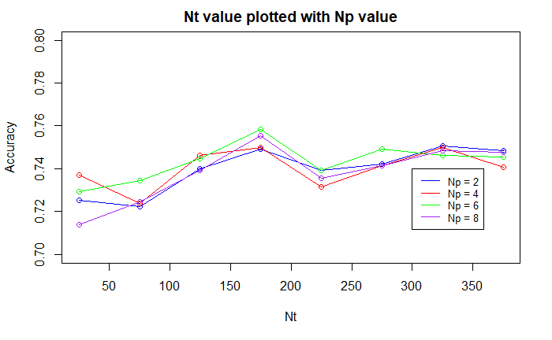

```r
legend(300,0.74,legend=c("Np = 2","Np = 4", "Np = 6","Np = 8"), col = c("blue","red","green","purple"), lty=1:1, cex = 0.8)
```

```r
NA
NA
```

## 3.2

```r
#================================
train.control <- trainControl(
  method = "cv",
  number = 5,
  search = "grid")

# tune grid in the format that is used by the ranger package.
#min node size 1 is equal to classification.

tgrid <- expand.grid(.mtry=c(np_best))

#vector to hold the values of the
resultsRF <- c()

#add in best model details for training here and run 15 times.
for(i in (1:15) ) {

  rf_fit <- train(label ~ .,
                  data = reducedfeaturesDataset,
                  method = "rf",
                  trControl = fit_control,
                  tuneGrid = tgrid,
                  ntree = nt_best)


  resultsRF = rbind(resultsRF, rf_fit$results$Accuracy)

}

resultsRF
```

```
           [,1]
 [1,] 0.7376923
 [2,] 0.7500000
 [3,] 0.7384615
 [4,] 0.7423077
 [5,] 0.7361538
 [6,] 0.7515385
 [7,] 0.7369231
 [8,] 0.7223077
 [9,] 0.7376923
[10,] 0.7484615
[11,] 0.7261538
[12,] 0.7215385
[13,] 0.7438462
[14,] 0.7323077
[15,] 0.7438462
```

```r
mean(resultsRF[,1])
```

```
[1] 0.7379487
```

```r
sd(resultsRF[,1])
```

```
[1] 0.009329448
```

## Conclusion

The report focuses on Modeling and machine learning to create an algorithm to predict the classifier of the data set and given data set.

I discovered many different techniques and examined and compared the accuracy results against each other.

I thoroughly enjoyed this assignment as my R skills have grown since the previous assignment and I applied lateral thinking and solutions to problems which arouse during the coding.

You can have data without information but not information without data is key thing I learnt through this assignment as I created different visualizations.